# cp2021-F07-Q02

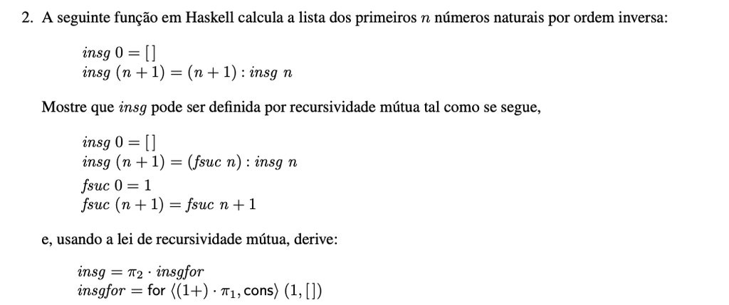

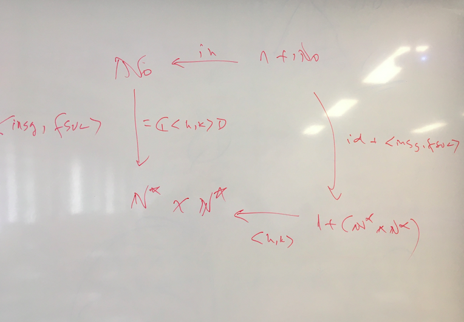

```haskell
-- loading CP libs
:opt no-lint
:load ../src/Cp.hs
:load ../src/Nat.hs
:set -XNPlusKPatterns
```

```haskell
insg 0 = []
insg (n+1) = (n+1):insg n

insg 7
```

```
[7,6,5,4,3,2,1]
```

```haskell
insg 0 = []
insg (n+1) = fsuc n : insg n
fsuc 0 = 1
fsuc (n+1) = fsuc n + 1
```

```haskell
insg 7
```

```
[7,6,5,4,3,2,1]
```

### Resolução (i)

$\def\cata#1{\mathopen{(\!|}#1\mathclose{|\!)}}\def\kons#1{\underline{#1}}$ $<insg, fsuc> = \cata{<[\kons{[]},cons . swap],[\kons{1},succ . \pi_2]>}$

{ Fokkinga }

$insg . in = [\kons{[]},cons . swap] . (id + <insg, fsuc>)$

$fsuc . in = [\kons{1},succ . \pi_2] . (id + <insg, fsuc>)$

{ $in = [\kons{0}, succ]$ ; fusão-$+$; absorção-$+$ }

$[insg . \kons{0}, insg . succ] = [\kons{[]} . id,cons . swap . <insg, fsuc>]$

$[fsuc . \kons{0}, fsuc . succ] = [\kons{1} . id,succ . \pi_2 . <insg, fsuc>]$

{ natural-id ; swap . <f,g> = <g,f> }

$[insg . \kons{0}, insg . succ] = [\kons{[]} ,cons . <fsuc, insg>]$

$[fsuc . \kons{0}, fsuc . succ] = [\kons{1},succ . fsuc]$

{ eq-$+$ }

$insg . \kons{0} = \kons{[]}$

$insg . succ = cons . <fsuc, insg>$

$fsuc . \kons{0} = \kons{1}$

$fsuc . succ = succ . fsuc$

{ pointwise; def-comp }

$insg \ 0 = []$

$insg \ (n + 1) = cons (fsuc \ n, insg \ n)$

$fsuc \ 0 = 1$

$fsuc \ (n + 1) = fsuc \ n + 1$

### Resolução (ii)

$\def\cata#1{\mathopen{(\!|}#1\mathclose{|\!)}}\def\kons#1{\underline{#1}}$ $insg = \pi_2 . insgfor$ ; $insgfor = for \ < succ . \pi_1,cons > \ (1,[])>$

{ $for \ b \ i = \cata{ [\kons{i}, b] }$ ; $\kons{(1,[])} = <\kons{1},\kons{[]}>$ }

$insgfor = \cata{[<\kons{1},\kons{[]}>,<succ . \pi_1,cons>]}$

{ universal-cata }

$\equiv insgfor . in = [<\kons{1},\kons{[]}>,<succ . \pi_1,cons>] . F \ insgfor$

{ $in = [\kons{0}, succ]$ ; $F \ insgfor = id + insgfor$ }

$\equiv insgfor . [\kons{0}, succ] = [<\kons{1},\kons{[]}>,<succ . \pi_1,cons>] . (id + insgfor)$

{ fusão-$+$ ; absorção-$+$ }

$\equiv [insgfor . \kons{0}, insgfor . succ] = [<\kons{1},\kons{[]}> . id,<succ . \pi_1,cons> . insgfor]$

{ natural-id ; fusão$\times$ }

$\equiv [insgfor . \kons{0}, insgfor . succ] = [<\kons{1} , \kons{[]}>, <succ . \pi_1 . insgfor, cons . insgfor>]$

{ eq-$+$ }

$insgfor . \kons{0} = <\kons{1} , \kons{[]}>$

$insgfor . succ = <succ . \pi_1 . insgfor, cons . insgfor>$

{ pointwise ; def-comp }

$insgfor \ (\kons{0} \ n) = <\kons{1} , \kons{[]}> \ n$

$insgfor \ (succ \ n) = <succ . \pi_1 . insgfor, cons . insgfor> \ n$

{ def-const; def-split ; succ n = n + 1}

$insgfor \ 0 = (\kons{1} \ n, \kons{[]} \ n)$

$insgfor \ (n + 1) = (\pi_1 (insgfor \ n) + 1, cons (insgfor \ n))$

{ def.const }

$insgfor \ 0 = (1, [])$

$insgfor \ (n + 1) = (\pi_1 (insgfor \ n) + 1, cons (insgfor\ n))$

```haskell
insgfor 0 = (1,[])
insgfor (n+1) = (p1(insgfor n) + 1,cons(insgfor n))

--type checking

:t insgfor

-- testing

insg = p2 . insgfor

insg 5
```

insgfor :: forall t a. (Integral t, Num a) => t -> (a, [a])

```
[5,4,3,2,1]
```